# 16_calibration_curves

### [Probability calibrarion](https://scikit-learn.org/stable/modules/calibration.html)

- Classification requires both prediction of class labels **and** finding a confidence of a correct label.
- Some classifiers can do this via `predict_proba`, but not all.

### [Example: Classifier Confidence Comparison](https://scikit-learn.org/stable/auto_examples/calibration/plot_compare_calibration.html)

- A well-calibrated classifier should, for example, return a `predict_proba` value of ~0.8 (~80% of labels predicted correctly).
- **Logistic Regression** does this - it directly optimizes log-loss.
- **Gaussian Naive Bayes** pushes probabilities towards 0 or 1, because it assumes features are independent per class. (Not the case in this example.)
- **Random Forest**, like most bagging methods, has difficulty making predictions near 0 or 1. The dataset's variance will bias samples that *should be near 0 or 1* away from those extremes. Random Forests are especially prone to this, because base-level trees have relatively high variance. So their calibration curves typically take a sigmoid shape.
- **Support Vector Classification** also takes on a sigmoid shape, which is typical for methods that concentrate on samples close to the decision boundary (the support vectors).

```python
import numpy as np
np.random.seed(0)

import matplotlib.pyplot as plt
from sklearn import datasets
from sklearn.naive_bayes import GaussianNB as GNB
from sklearn.linear_model import LogisticRegression as LR
from sklearn.ensemble import RandomForestClassifier as RFC
from sklearn.svm import LinearSVC as LSVC
from sklearn.calibration import calibration_curve as CC
```

```python
X, y = datasets.make_classification(n_samples=100000, n_features=20,
                                    n_informative=2, n_redundant=2)

train_samples = 100

X_train = X[:train_samples];   X_test = X[train_samples:]
y_train = y[:train_samples];   y_test = y[train_samples:]
```

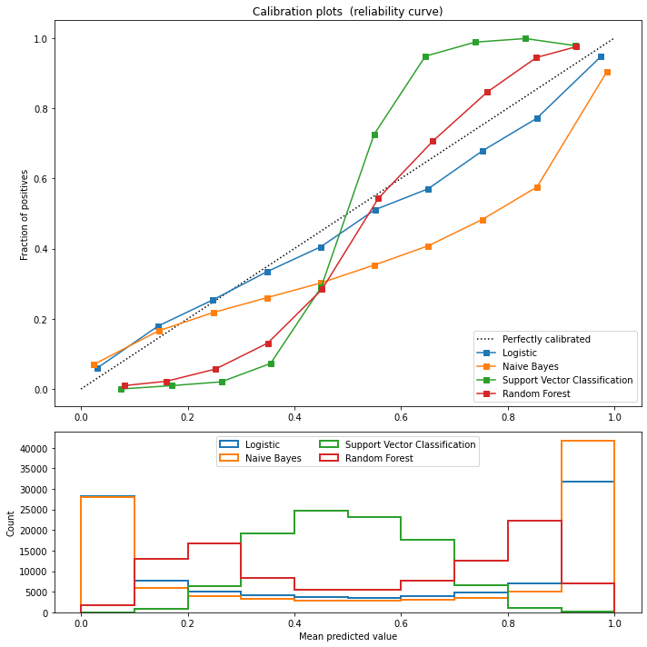

```python
plt.figure(figsize=(10, 10))
ax1 = plt.subplot2grid((3, 1), (0, 0), rowspan=2)
ax2 = plt.subplot2grid((3, 1), (2, 0))

ax1.plot([0, 1], [0, 1], "k:", label="Perfectly calibrated")
for clf, name in [(LR(),        'Logistic'),
                  (GNB(),       'Naive Bayes'),
                  (LSVC(C=1.0), 'Support Vector Classification'),
                  (RFC(),       'Random Forest')]:
    clf.fit(X_train, y_train)

    if hasattr(clf, "predict_proba"):
        prob_pos = clf.predict_proba(X_test)[:, 1]
    else:  # use decision function
        prob_pos = clf.decision_function(X_test)
        prob_pos = (prob_pos - prob_pos.min()) / (prob_pos.max() - prob_pos.min())

    fraction_of_positives, mean_predicted_value = \
        CC(y_test, prob_pos, n_bins=10)

    ax1.plot(mean_predicted_value,
             fraction_of_positives, "s-",
             label="%s" % (name, ))

    ax2.hist(prob_pos, range=(0, 1), bins=10, label=name,
             histtype="step", lw=2)

ax1.set_ylabel("Fraction of positives")
ax1.set_ylim([-0.05, 1.05])
ax1.legend(loc="lower right")
ax1.set_title('Calibration plots  (reliability curve)')

ax2.set_xlabel("Mean predicted value")
ax2.set_ylabel("Count")
ax2.legend(loc="upper center", ncol=2)

plt.tight_layout()
plt.show()
```

### Calibration

- Calibration is defined as fitting a regresssor (aka "calibrator") that maps a classifier output (via `decision_function` or `predict_proba`) to a calibrated probability in [0,1].
- The calibrator tries to predict $p(y_i = 1 | f_i)$.
- Do not fit the calibrator with the same data used for classifier fit - this will introduce bias.

### [Cross-Validation](https://scikit-learn.org/stable/modules/generated/sklearn.calibration.CalibratedClassifierCV.html#sklearn.calibration.CalibratedClassifierCV)

- Use this method to ensure the calibrator is always fitted with unbiased data. It splits data into k pairs of `(train_set, test_set)`.
- **`ensemble=True`** (default) tells the calibrator to do the following steps independently on each train-test pair:
  - Clone the `base_estimator` and train it on the training subset.
  - Predict labels on the test subset.
  - The predictions and a *regressor* (sigmoid or isotonic - see below) to fit a calibrator.
  - This returns an ensemble of $k$ `(classifier, calibrator)` pairs.
  - Each pair is available in `calibrated_classifiers_`.
  - `predict_proba` for the main instance is the average of the $k$ estimators in the list.
  - `predict` returns the class with the highest probability.
- **`ensemble=False`** tells the calibrator to find unbiased predictions for the entire dataset via cross_val_predict.
  - `calibrated_classifiers_` contains only one `(classifier, calibrator)` pair - the classifier is the `base_estimator` trained on all data.
  - `predict_proba` is the predicted probabilities from the single pair.
- `ensemble=True` should return slightly better accuracy, as it benefits from typical ensemble effects. `ensemble=False` is better when computation time is a concern.
- You can use `cv="prefit"` if a prefitted classifier is already available.

### Metrics

- [brier score loss](https://scikit-learn.org/stable/modules/generated/sklearn.metrics.brier_score_loss.html#sklearn.metrics.brier_score_loss) can be used to assess calibration performance.
  - Brier scores are a combination of *calibration* and *refinement* losses.
  - Refinement losses can change independently of calibration losses - so lower Brier scores do not necessarily indicate better calibration.

### Regressors

- The **Sigmoid** regressor is based on this logistic model: $p(y_i = 1 | f_i) = \frac{1}{1 + \exp(A f_i + B)}$, ($y_i$ is the true label of sample $i$, $f_i$ is the uncalibrated classifier output for that sample. $A$ & $B$ are found via maximum likelihood.
- The sigmoid method assumes calibration curves can be corrected by applying a sigmoid function to raw predictions.
- This method is most effective when the uncalibrated model is under-confident, and has similar errors for both high & low outputs.
- The **Isotonic** regressor returns a non-decreasing function. It minimizes $\sum_{i=1}^{n} (y_i - \hat{f}_i)^2$.
- The Isotonic method is more general-purpose than sigmoids - the only restriction is the mapping function needing to be monotonically increasing. It is more prone to overfitting on small datasets.
- This method can be more effective when there is enough data (>1K samples) to avoid overfitting.

### Multiclass support

- Both regressors only support 1D data (binary classification), but are extended for multiclass classification if the `base_estimator` supports it.